# Practical Machine Learning: Predicting excercise quality grade

Alex Baranov

March 11, 2015

## Synopsis

This project is to build and algorithm which will analyze the data, collected from accelerometers on the belt, forearm, arm, and dumbell of 6 participants. They were asked to perform barbell lifts correctly and incorrectly in 5 different ways.

Once algorithm is trained it should be able to automatically grade quality of an excercise, when given the data form the sensors.

For this project I will be using the data by Human Activity Recognition project - http://groupware.les.inf.puc-rio.br/har (see the section on the Weight Lifting Exercise Dataset).

### Loading the data

```r
setwd("~/MyDigilife/Labs/Cousera/R/MachineLearning")
if (!file.exists("pml-training.csv") | !file.exists("pml-testing.csv")) {
  download.file("http://d396qusza40orc.cloudfront.net/predmachlearn/pml-training.csv", "pml-training.csv")
  download.file("http://d396qusza40orc.cloudfront.net/predmachlearn/pml-testing.csv", "pml-testing.csv")
}

training <- read.csv("pml-training.csv", na.strings=c('#DIV/0!', '', 'NA'))
testing <- read.csv("pml-testing.csv", na.strings=c('#DIV/0!', '', 'NA'))
```

### Cleaning data and splitting data for training and testing subsets

```r
keep.columns <- colSums(is.na(training)) < (nrow(training) * 0.9) # finding columns where NA values count is less than 90% of total row count.

training.tidy <- training[,keep.columns]
training.tidy <- training.tidy[, !names(training.tidy) %in% c('X', 'user_name', 'raw_timestamp_part_1', 'raw_timestamp_part_2', 'cvtd_timestamp', 'new_window', 'num_window')] # taking out colums which do not affect 'classe' in any way

testing.tidy <- testing[,keep.columns]
testing.tidy <- testing.tidy[, !names(testing.tidy) %in% c('X', 'user_name', 'raw_timestamp_part_1', 'raw_timestamp_part_2', 'cvtd_timestamp', 'new_window', 'num_window')] # taking out colums which do not affect 'classe' in any way

library(caret)
inTrain <- createDataPartition(y=training.tidy$classe, p=0.7, list=FALSE)
training.model <- training.tidy[inTrain,]
testing.model <- training.tidy[-inTrain,]
```

### Exploring the data

```r
library(caret)
```

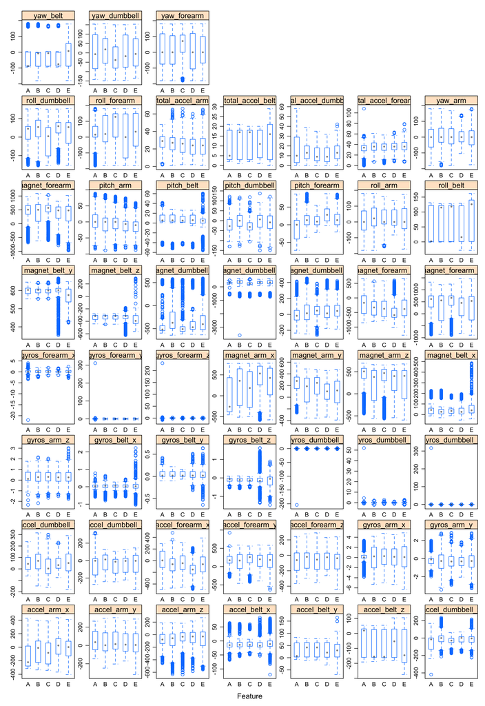

```r
#str(training.model)     # commenting out as the output is too long
#summary(training.model)
featurePlot(training.model[,colnames(training.model)[-length(colnames(training.model))]], y=training.model$classe, pch = 16, col=adjustcolor("black", alpha=0.5), cex=0.5, scales=list(x=list(relation="free"), y=list(relation="free")), layout = c(7,8), plot="box")
```

We see a big set of varibles, it is quite difficult to understand from first glance which of the features contibute the most to the final score and how. So I will be using random forest algorithm to train the model and then cross-validate the results.

### Training the model

```r
library(SOAR)

# As calculating model on all variables took me around 20 hours, I'll cache final model using SOAR package
# Limiting number of variable would probably speed the process up, but I've decide to go with full set.
if (!match('modFit', Objects())) {
  modFit <- train(classe ~ ., data=training.model, metod="rf", prox=TRUE)
  Store(modFit)
}
```

Now lets check out resulting model details and expected errors

```r
modFit
```

```
## Random Forest
##
## 13737 samples
##    52 predictor
##     5 classes: 'A', 'B', 'C', 'D', 'E'
##
## No pre-processing
## Resampling: Bootstrapped (25 reps)
##
## Summary of sample sizes: 13737, 13737, 13737, 13737, 13737, 13737, ...
##
## Resampling results across tuning parameters:
##
##   mtry  Accuracy   Kappa      Accuracy SD  Kappa SD
##    2    0.9876535  0.9843723  0.001602720  0.002031811
##   27    0.9880916  0.9849275  0.001700258  0.002156220
##   52    0.9799216  0.9745869  0.003890447  0.004921451
##
## Accuracy was used to select the optimal model using  the largest value.
## The final value used for the model was mtry = 27.
```

### Cross validation

```r
ptm <- predict(modFit, testing.model[, !names(testing.model) %in% c("classe")])
table(ptm, testing.model$classe)
```

```
##
## ptm    A    B    C    D    E
##   A 1672    2    0    0    0
##   B    1 1137    3    0    0
##   C    0    0 1023    0    2
##   D    0    0    0  964    1
##   E    1    0    0    0 1079
```